# Untitled

Anna Syreeni

21 marraskuuta 2018

# Week4: Clustering and classification

**Exploring Boston-data**

For this week’s excersize we’ll use a Boston-dataset included in the MASS Package in R. Basically, the data is about per capita crime rate by town and some variables describing the towns. There are 14 variables on 506 towns included.

The variables in the Boston data are:  
crim = per capita crime rate by town  
zn = proportion of residential land zoned for lots over 25,000 sq.ft  
indus = proportion of non-retail business acres per town  
chas = Charles River dummy variable (= 1 if tract bounds river; 0 otherwise)  
nox = nitrogen oxides concentration (parts per 10 million)  
rm = average number of rooms per dwelling  
age = proportion of owner-occupied units built prior to 1940  
dis = weighted mean of distances to five Boston employment centres  
rad = index of accessibility to radial highways  
tax = full-value property-tax rate per $10,000  
ptratio = pupil-teacher ratio by town  
black = 1000(Bk - 0.63)^2 where Bk is the proportion of blacks by town  
lstat = lower status of the population (percent)  
medv = median value of owner-occupied homes in $1000s

The summaries of all variables are listed below. As seen from the summary, for example crime rate differs largely between towns: it ranges from 0.006 crimes from 89.0 crimes per capita.

```
##       crim                zn             indus            chas
##  Min.   : 0.00632   Min.   :  0.00   Min.   : 0.46   Min.   :0.00000
##  1st Qu.: 0.08204   1st Qu.:  0.00   1st Qu.: 5.19   1st Qu.:0.00000
##  Median : 0.25651   Median :  0.00   Median : 9.69   Median :0.00000
##  Mean   : 3.61352   Mean   : 11.36   Mean   :11.14   Mean   :0.06917
##  3rd Qu.: 3.67708   3rd Qu.: 12.50   3rd Qu.:18.10   3rd Qu.:0.00000
##  Max.   :88.97620   Max.   :100.00   Max.   :27.74   Max.   :1.00000
##       nox               rm             age              dis
##  Min.   :0.3850   Min.   :3.561   Min.   :  2.90   Min.   : 1.130
##  1st Qu.:0.4490   1st Qu.:5.886   1st Qu.: 45.02   1st Qu.: 2.100
##  Median :0.5380   Median :6.208   Median : 77.50   Median : 3.207
##  Mean   :0.5547   Mean   :6.285   Mean   : 68.57   Mean   : 3.795
##  3rd Qu.:0.6240   3rd Qu.:6.623   3rd Qu.: 94.08   3rd Qu.: 5.188
##  Max.   :0.8710   Max.   :8.780   Max.   :100.00   Max.   :12.127
##       rad              tax           ptratio          black
##  Min.   : 1.000   Min.   :187.0   Min.   :12.60   Min.   :  0.32
##  1st Qu.: 4.000   1st Qu.:279.0   1st Qu.:17.40   1st Qu.:375.38
##  Median : 5.000   Median :330.0   Median :19.05   Median :391.44
##  Mean   : 9.549   Mean   :408.2   Mean   :18.46   Mean   :356.67
##  3rd Qu.:24.000   3rd Qu.:666.0   3rd Qu.:20.20   3rd Qu.:396.23
##  Max.   :24.000   Max.   :711.0   Max.   :22.00   Max.   :396.90
##      lstat            medv
##  Min.   : 1.73   Min.   : 5.00
##  1st Qu.: 6.95   1st Qu.:17.02
##  Median :11.36   Median :21.20
##  Mean   :12.65   Mean   :22.53
##  3rd Qu.:16.95   3rd Qu.:25.00
##  Max.   :37.97   Max.   :50.00
```

As seen from the correlation matrix, for example accessibility to radial highways (rad, calculated correlation r=0.63) and full-value propery-tax rate (tax, calculated r = 0.58) correlate positively with per capita crime rate. Living far Boston five Boston employment centres associates with lower air nitric oxide concentration (correlation of dis and nos, r = -0.77)

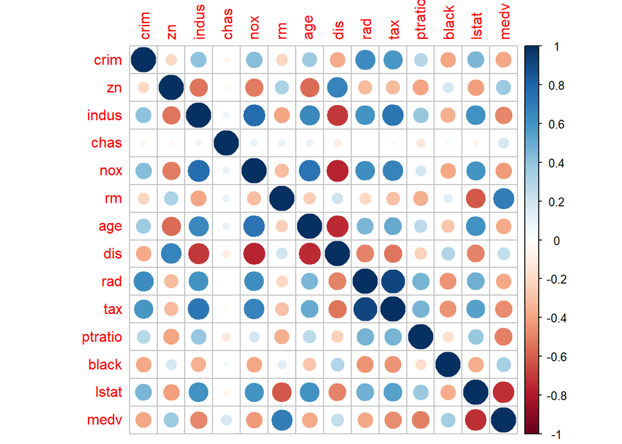

Next I standarsized all variables in the Boston data. Summaries of the variables are printed below. You can easily see that all standarized variables now have a mean of 0.

```
##       crim                 zn               indus
##  Min.   :-0.419367   Min.   :-0.48724   Min.   :-1.5563
##  1st Qu.:-0.410563   1st Qu.:-0.48724   1st Qu.:-0.8668
##  Median :-0.390280   Median :-0.48724   Median :-0.2109
##  Mean   : 0.000000   Mean   : 0.00000   Mean   : 0.0000
##  3rd Qu.: 0.007389   3rd Qu.: 0.04872   3rd Qu.: 1.0150
##  Max.   : 9.924110   Max.   : 3.80047   Max.   : 2.4202
##       chas              nox                rm               age
##  Min.   :-0.2723   Min.   :-1.4644   Min.   :-3.8764   Min.   :-2.3331
##  1st Qu.:-0.2723   1st Qu.:-0.9121   1st Qu.:-0.5681   1st Qu.:-0.8366
##  Median :-0.2723   Median :-0.1441   Median :-0.1084   Median : 0.3171
##  Mean   : 0.0000   Mean   : 0.0000   Mean   : 0.0000   Mean   : 0.0000
##  3rd Qu.:-0.2723   3rd Qu.: 0.5981   3rd Qu.: 0.4823   3rd Qu.: 0.9059
##  Max.   : 3.6648   Max.   : 2.7296   Max.   : 3.5515   Max.   : 1.1164
##       dis               rad               tax             ptratio
##  Min.   :-1.2658   Min.   :-0.9819   Min.   :-1.3127   Min.   :-2.7047
##  1st Qu.:-0.8049   1st Qu.:-0.6373   1st Qu.:-0.7668   1st Qu.:-0.4876
##  Median :-0.2790   Median :-0.5225   Median :-0.4642   Median : 0.2746
##  Mean   : 0.0000   Mean   : 0.0000   Mean   : 0.0000   Mean   : 0.0000
##  3rd Qu.: 0.6617   3rd Qu.: 1.6596   3rd Qu.: 1.5294   3rd Qu.: 0.8058
##  Max.   : 3.9566   Max.   : 1.6596   Max.   : 1.7964   Max.   : 1.6372
##      black             lstat              medv
##  Min.   :-3.9033   Min.   :-1.5296   Min.   :-1.9063
##  1st Qu.: 0.2049   1st Qu.:-0.7986   1st Qu.:-0.5989
##  Median : 0.3808   Median :-0.1811   Median :-0.1449
##  Mean   : 0.0000   Mean   : 0.0000   Mean   : 0.0000
##  3rd Qu.: 0.4332   3rd Qu.: 0.6024   3rd Qu.: 0.2683
##  Max.   : 0.4406   Max.   : 3.5453   Max.   : 2.9865
```

For further analysis, a cathegorical variable from the scaled crime rate was created (quartiles). This variable now divides the crime rate to “low”, “medium low”, “medium high” and “high” -cathegories.

[output not shown]

Next the Boston data was divided into training and test sets. Randomly chosen 80% belongs to the training set, and the rest is in test-set.

**Linear discrimant analysis**

Linear discrimant analysis of the Boston data shows that variable rad meaning accessibility to radial highways, is a very strong predictor for a town to belong to a group of high crime rate.

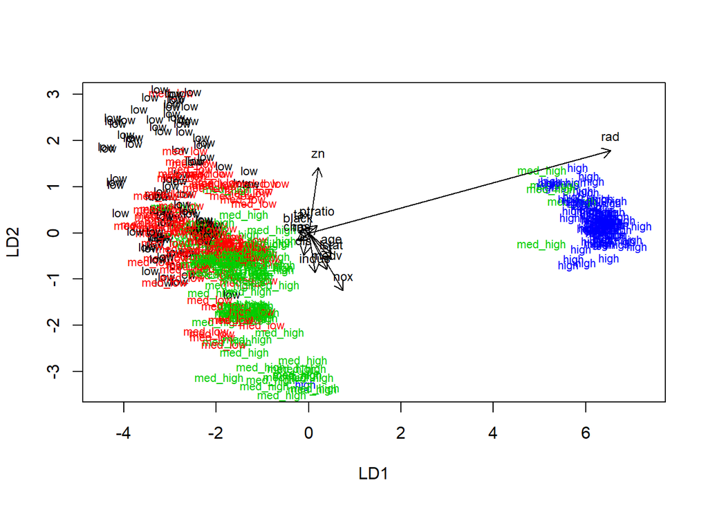

```
##           predicted
## correct    low med_low med_high high
##   low       13      10        3    0
##   med_low    6      14        3    0
##   med_high   0      15       10    1
##   high       0       0        0   27
```

```
##           predicted
## correct        low med_low med_high    high
##   low      0.50000 0.38462  0.11538 0.00000
##   med_low  0.26087 0.60870  0.13043 0.00000
##   med_high 0.00000 0.57692  0.38462 0.03846
##   high     0.00000 0.00000  0.00000 1.00000
```

**Distances in the Boston data and clustering**

```r
data("Boston")
#str(Boston)
# center and standardize variables
boston_scaled <- scale(Boston)

# summaries of the scaled variables
#summary(boston_scaled)
```

*K-means clustering*

For the k-means cluster, an optimal number of clusters can be decided from the figure below showing number of clusters (1-10) on the x-axis and within class sum of squares (**WCSS**) on the y-axis. As seen from the figure, 2 clusters seem to be the most optimal for clustring.

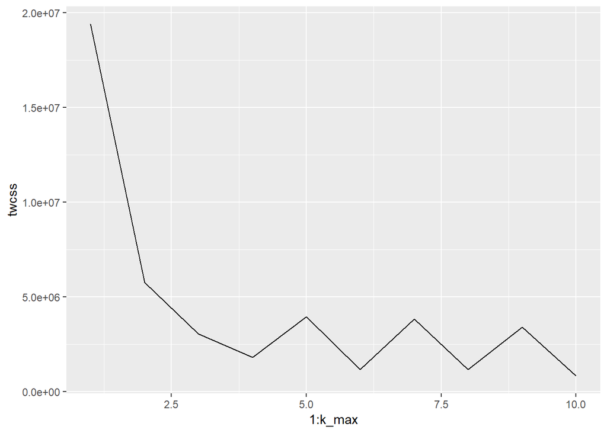

```r
# k-means clustering
# MASS, ggplot2 and Boston dataset are available
# K-means might produce different results every time, because it randomly # assigns the initial cluster centers. The function set.seed() can be used # to deal with that.
set.seed(123)

# determine the number of clusters
k_max <- 10

# calculate the total within sum of squares
twcss <- sapply(1:k_max, function(k){kmeans(Boston, k)$tot.withinss})

# visualize the WCSS results
qplot(x = 1:k_max, y = twcss, geom = 'line')
```

```r
# k-means clustering
km <-kmeans(boston_scaled, centers = 2)

# plot the Boston dataset with clusters
dim(boston_scaled)
```

```
## [1] 506  14
```

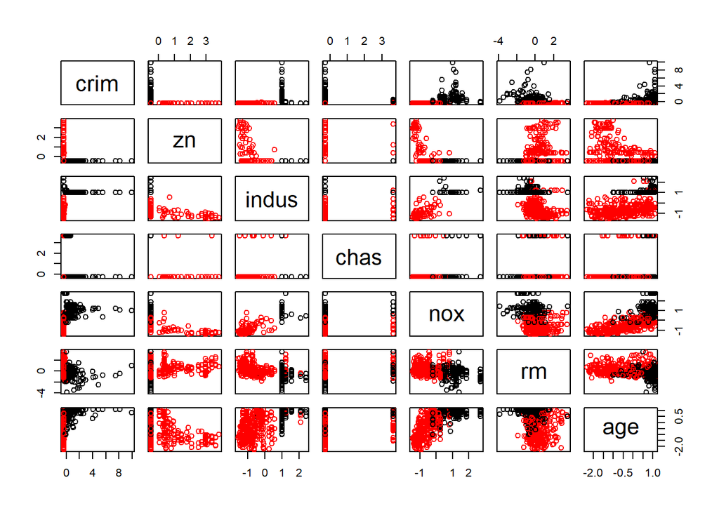

```r
par(mfrow = c(2,1))
pairs(boston_scaled[,1:7], col = km$cluster)
```

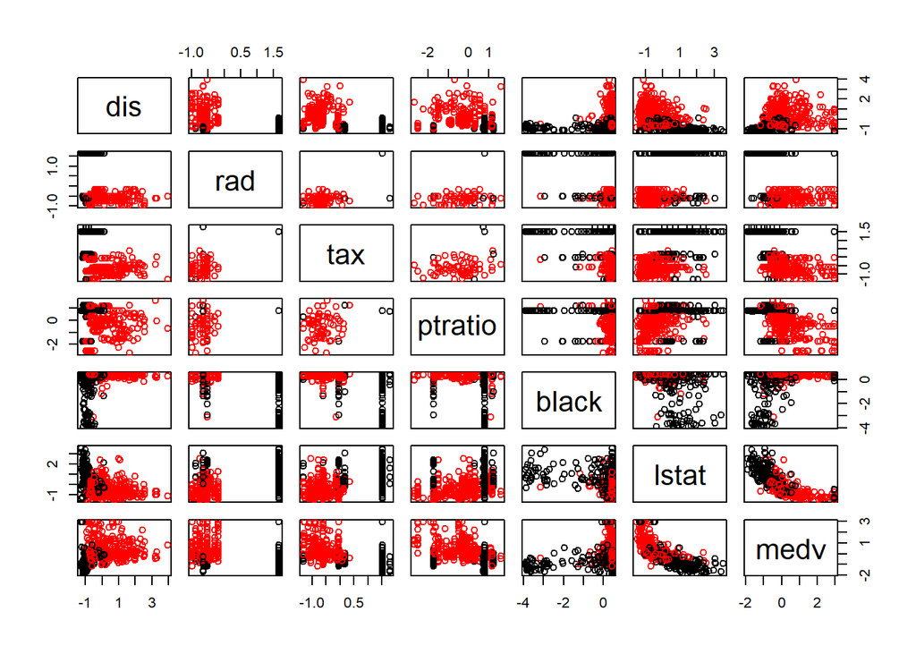

[output not shown]

```r
pairs(boston_scaled[,8:14], col = km$cluster)
```